# Risk Factor Analysis

## Outcome Variable

**Outcome Variable:** sstunted

## Predictor Variables

**Intervention Variable:** birthwt

**Adjustment Set:**

unadjusted

## Stratifying Variables

The analysis was stratified on these variable(s):

- agecat
- studyid
- country

## Data Summary

| agecat | studyid | country | birthwt | sstunted | n_cell | n |
| --- | --- | --- | --- | --- | --- | --- |
| Birth | ki0047075b-MAL-ED | BANGLADESH | Normal or high birthweight | 0 | 201 | 257 |
| Birth | ki0047075b-MAL-ED | BANGLADESH | Normal or high birthweight | 1 | 1 | 257 |
| Birth | ki0047075b-MAL-ED | BANGLADESH | Low birth weight | 0 | 47 | 257 |
| Birth | ki0047075b-MAL-ED | BANGLADESH | Low birth weight | 1 | 8 | 257 |
| Birth | ki0047075b-MAL-ED | BRAZIL | Normal or high birthweight | 0 | 179 | 191 |
| Birth | ki0047075b-MAL-ED | BRAZIL | Normal or high birthweight | 1 | 4 | 191 |
| Birth | ki0047075b-MAL-ED | BRAZIL | Low birth weight | 0 | 4 | 191 |
| Birth | ki0047075b-MAL-ED | BRAZIL | Low birth weight | 1 | 4 | 191 |
| Birth | ki0047075b-MAL-ED | INDIA | Normal or high birthweight | 0 | 168 | 206 |
| Birth | ki0047075b-MAL-ED | INDIA | Normal or high birthweight | 1 | 4 | 206 |
| Birth | ki0047075b-MAL-ED | INDIA | Low birth weight | 0 | 31 | 206 |
| Birth | ki0047075b-MAL-ED | INDIA | Low birth weight | 1 | 3 | 206 |
| Birth | ki0047075b-MAL-ED | NEPAL | Normal or high birthweight | 0 | 154 | 173 |
| Birth | ki0047075b-MAL-ED | NEPAL | Normal or high birthweight | 1 | 1 | 173 |
| Birth | ki0047075b-MAL-ED | NEPAL | Low birth weight | 0 | 13 | 173 |
| Birth | ki0047075b-MAL-ED | NEPAL | Low birth weight | 1 | 5 | 173 |
| Birth | ki0047075b-MAL-ED | PERU | Normal or high birthweight | 0 | 267 | 287 |
| Birth | ki0047075b-MAL-ED | PERU | Normal or high birthweight | 1 | 2 | 287 |
| Birth | ki0047075b-MAL-ED | PERU | Low birth weight | 0 | 12 | 287 |
| Birth | ki0047075b-MAL-ED | PERU | Low birth weight | 1 | 6 | 287 |
| Birth | ki0047075b-MAL-ED | SOUTH AFRICA | Normal or high birthweight | 0 | 244 | 262 |
| Birth | ki0047075b-MAL-ED | SOUTH AFRICA | Normal or high birthweight | 1 | 0 | 262 |
| Birth | ki0047075b-MAL-ED | SOUTH AFRICA | Low birth weight | 0 | 16 | 262 |
| Birth | ki0047075b-MAL-ED | SOUTH AFRICA | Low birth weight | 1 | 2 | 262 |
| Birth | ki0047075b-MAL-ED | TANZANIA, UNITED REPUBLIC OF | Normal or high birthweight | 0 | 113 | 123 |
| Birth | ki0047075b-MAL-ED | TANZANIA, UNITED REPUBLIC OF | Normal or high birthweight | 1 | 3 | 123 |
| Birth | ki0047075b-MAL-ED | TANZANIA, UNITED REPUBLIC OF | Low birth weight | 0 | 4 | 123 |
| Birth | ki0047075b-MAL-ED | TANZANIA, UNITED REPUBLIC OF | Low birth weight | 1 | 3 | 123 |
| Birth | ki1000108-CMC-V-BCS-2002 | INDIA | Normal or high birthweight | 0 | 77 | 90 |
| Birth | ki1000108-CMC-V-BCS-2002 | INDIA | Normal or high birthweight | 1 | 3 | 90 |

[output cut: 286 more lines]

The following strata were considered:

- agecat: 24 months, studyid: ki0047075b-MAL-ED, country: BANGLADESH
- agecat: 24 months, studyid: ki0047075b-MAL-ED, country: BRAZIL
- agecat: 24 months, studyid: ki0047075b-MAL-ED, country: INDIA
- agecat: 24 months, studyid: ki0047075b-MAL-ED, country: NEPAL
- agecat: 24 months, studyid: ki0047075b-MAL-ED, country: PERU
- agecat: 24 months, studyid: ki0047075b-MAL-ED, country: SOUTH AFRICA
- agecat: 24 months, studyid: ki0047075b-MAL-ED, country: TANZANIA, UNITED REPUBLIC OF
- agecat: 24 months, studyid: ki1000108-CMC-V-BCS-2002, country: INDIA
- agecat: 24 months, studyid: ki1000108-IRC, country: INDIA
- agecat: 24 months, studyid: ki1017093-NIH-Birth, country: BANGLADESH
- agecat: 24 months, studyid: ki1017093b-PROVIDE, country: BANGLADESH
- agecat: 24 months, studyid: ki1017093c-NIH-Crypto, country: BANGLADESH
- agecat: 24 months, studyid: ki1066203-TanzaniaChild2, country: TANZANIA, UNITED REPUBLIC OF
- agecat: 24 months, studyid: ki1101329-Keneba, country: GAMBIA
- agecat: 24 months, studyid: ki1114097-CMIN, country: BANGLADESH
- agecat: 24 months, studyid: ki1114097-CMIN, country: PERU
- agecat: 24 months, studyid: ki1114097-CONTENT, country: PERU
- agecat: 24 months, studyid: ki1119695-PROBIT, country: BELARUS
- agecat: 24 months, studyid: ki1126311-ZVITAMBO, country: ZIMBABWE
- agecat: 24 months, studyid: ki1135781-COHORTS, country: GUATEMALA
- agecat: 24 months, studyid: ki1135781-COHORTS, country: INDIA
- agecat: 24 months, studyid: ki1135781-COHORTS, country: PHILIPPINES
- agecat: 24 months, studyid: kiGH5241-JiVitA-3, country: BANGLADESH
- agecat: 24 months, studyid: kiGH5241-JiVitA-4, country: BANGLADESH
- agecat: 6 months, studyid: ki0047075b-MAL-ED, country: BANGLADESH
- agecat: 6 months, studyid: ki0047075b-MAL-ED, country: BRAZIL
- agecat: 6 months, studyid: ki0047075b-MAL-ED, country: INDIA
- agecat: 6 months, studyid: ki0047075b-MAL-ED, country: NEPAL
- agecat: 6 months, studyid: ki0047075b-MAL-ED, country: PERU
- agecat: 6 months, studyid: ki0047075b-MAL-ED, country: SOUTH AFRICA
- agecat: 6 months, studyid: ki0047075b-MAL-ED, country: TANZANIA, UNITED REPUBLIC OF
- agecat: 6 months, studyid: ki1000108-CMC-V-BCS-2002, country: INDIA
- agecat: 6 months, studyid: ki1000108-IRC, country: INDIA
- agecat: 6 months, studyid: ki1000109-EE, country: PAKISTAN
- agecat: 6 months, studyid: ki1000109-ResPak, country: PAKISTAN
- agecat: 6 months, studyid: ki1000304b-SAS-CompFeed, country: INDIA
- agecat: 6 months, studyid: ki1017093-NIH-Birth, country: BANGLADESH
- agecat: 6 months, studyid: ki1017093b-PROVIDE, country: BANGLADESH
- agecat: 6 months, studyid: ki1017093c-NIH-Crypto, country: BANGLADESH
- agecat: 6 months, studyid: ki1066203-TanzaniaChild2, country: TANZANIA, UNITED REPUBLIC OF
- agecat: 6 months, studyid: ki1101329-Keneba, country: GAMBIA
- agecat: 6 months, studyid: ki1114097-CMIN, country: BANGLADESH
- agecat: 6 months, studyid: ki1114097-CMIN, country: BRAZIL
- agecat: 6 months, studyid: ki1114097-CMIN, country: GUINEA-BISSAU
- agecat: 6 months, studyid: ki1114097-CMIN, country: PERU
- agecat: 6 months, studyid: ki1114097-CONTENT, country: PERU
- agecat: 6 months, studyid: ki1119695-PROBIT, country: BELARUS
- agecat: 6 months, studyid: ki1126311-ZVITAMBO, country: ZIMBABWE
- agecat: 6 months, studyid: ki1135781-COHORTS, country: GUATEMALA
- agecat: 6 months, studyid: ki1135781-COHORTS, country: INDIA
- agecat: 6 months, studyid: ki1135781-COHORTS, country: PHILIPPINES
- agecat: 6 months, studyid: kiGH5241-JiVitA-3, country: BANGLADESH
- agecat: 6 months, studyid: kiGH5241-JiVitA-4, country: BANGLADESH
- agecat: Birth, studyid: ki0047075b-MAL-ED, country: BANGLADESH
- agecat: Birth, studyid: ki0047075b-MAL-ED, country: BRAZIL
- agecat: Birth, studyid: ki0047075b-MAL-ED, country: INDIA
- agecat: Birth, studyid: ki0047075b-MAL-ED, country: NEPAL
- agecat: Birth, studyid: ki0047075b-MAL-ED, country: PERU
- agecat: Birth, studyid: ki0047075b-MAL-ED, country: SOUTH AFRICA
- agecat: Birth, studyid: ki0047075b-MAL-ED, country: TANZANIA, UNITED REPUBLIC OF
- agecat: Birth, studyid: ki1000108-CMC-V-BCS-2002, country: INDIA
- agecat: Birth, studyid: ki1000108-IRC, country: INDIA
- agecat: Birth, studyid: ki1000109-EE, country: PAKISTAN
- agecat: Birth, studyid: ki1000109-ResPak, country: PAKISTAN
- agecat: Birth, studyid: ki1000304b-SAS-CompFeed, country: INDIA
- agecat: Birth, studyid: ki1017093-NIH-Birth, country: BANGLADESH
- agecat: Birth, studyid: ki1017093c-NIH-Crypto, country: BANGLADESH
- agecat: Birth, studyid: ki1101329-Keneba, country: GAMBIA
- agecat: Birth, studyid: ki1114097-CMIN, country: BANGLADESH
- agecat: Birth, studyid: ki1114097-CMIN, country: BRAZIL
- agecat: Birth, studyid: ki1114097-CMIN, country: PERU
- agecat: Birth, studyid: ki1114097-CONTENT, country: PERU
- agecat: Birth, studyid: ki1119695-PROBIT, country: BELARUS
- agecat: Birth, studyid: ki1126311-ZVITAMBO, country: ZIMBABWE
- agecat: Birth, studyid: ki1135781-COHORTS, country: GUATEMALA
- agecat: Birth, studyid: ki1135781-COHORTS, country: INDIA
- agecat: Birth, studyid: ki1135781-COHORTS, country: PHILIPPINES
- agecat: Birth, studyid: kiGH5241-JiVitA-3, country: BANGLADESH
- agecat: Birth, studyid: kiGH5241-JiVitA-4, country: BANGLADESH

### Dropped Strata

Some strata were dropped due to rare outcomes:

- agecat: Birth, studyid: ki0047075b-MAL-ED, country: BANGLADESH
- agecat: Birth, studyid: ki0047075b-MAL-ED, country: BRAZIL
- agecat: Birth, studyid: ki0047075b-MAL-ED, country: INDIA
- agecat: Birth, studyid: ki0047075b-MAL-ED, country: NEPAL
- agecat: Birth, studyid: ki0047075b-MAL-ED, country: PERU
- agecat: Birth, studyid: ki0047075b-MAL-ED, country: SOUTH AFRICA
- agecat: Birth, studyid: ki0047075b-MAL-ED, country: TANZANIA, UNITED REPUBLIC OF
- agecat: Birth, studyid: ki1000108-CMC-V-BCS-2002, country: INDIA
- agecat: Birth, studyid: ki1000109-EE, country: PAKISTAN
- agecat: Birth, studyid: ki1000109-ResPak, country: PAKISTAN
- agecat: Birth, studyid: ki1000304b-SAS-CompFeed, country: INDIA
- agecat: Birth, studyid: ki1017093-NIH-Birth, country: BANGLADESH
- agecat: Birth, studyid: ki1017093c-NIH-Crypto, country: BANGLADESH
- agecat: Birth, studyid: ki1114097-CMIN, country: BANGLADESH
- agecat: Birth, studyid: ki1114097-CMIN, country: BRAZIL
- agecat: Birth, studyid: ki1114097-CMIN, country: PERU
- agecat: Birth, studyid: ki1114097-CONTENT, country: PERU
- agecat: Birth, studyid: ki1119695-PROBIT, country: BELARUS
- agecat: Birth, studyid: ki1135781-COHORTS, country: GUATEMALA
- agecat: Birth, studyid: kiGH5241-JiVitA-4, country: BANGLADESH
- agecat: 6 months, studyid: ki0047075b-MAL-ED, country: BANGLADESH
- agecat: 6 months, studyid: ki0047075b-MAL-ED, country: BRAZIL
- agecat: 6 months, studyid: ki0047075b-MAL-ED, country: INDIA
- agecat: 6 months, studyid: ki0047075b-MAL-ED, country: NEPAL
- agecat: 6 months, studyid: ki0047075b-MAL-ED, country: SOUTH AFRICA
- agecat: 6 months, studyid: ki0047075b-MAL-ED, country: TANZANIA, UNITED REPUBLIC OF
- agecat: 6 months, studyid: ki1000109-ResPak, country: PAKISTAN
- agecat: 6 months, studyid: ki1017093-NIH-Birth, country: BANGLADESH
- agecat: 6 months, studyid: ki1017093b-PROVIDE, country: BANGLADESH
- agecat: 6 months, studyid: ki1066203-TanzaniaChild2, country: TANZANIA, UNITED REPUBLIC OF
- agecat: 6 months, studyid: ki1114097-CMIN, country: BANGLADESH
- agecat: 6 months, studyid: ki1114097-CMIN, country: BRAZIL
- agecat: 6 months, studyid: ki1114097-CMIN, country: GUINEA-BISSAU
- agecat: 6 months, studyid: ki1114097-CMIN, country: PERU
- agecat: 6 months, studyid: ki1114097-CONTENT, country: PERU
- agecat: 6 months, studyid: ki1119695-PROBIT, country: BELARUS
- agecat: 24 months, studyid: ki0047075b-MAL-ED, country: BRAZIL
- agecat: 24 months, studyid: ki0047075b-MAL-ED, country: NEPAL
- agecat: 24 months, studyid: ki0047075b-MAL-ED, country: PERU
- agecat: 24 months, studyid: ki0047075b-MAL-ED, country: SOUTH AFRICA
- agecat: 24 months, studyid: ki0047075b-MAL-ED, country: TANZANIA, UNITED REPUBLIC OF
- agecat: 24 months, studyid: ki1066203-TanzaniaChild2, country: TANZANIA, UNITED REPUBLIC OF
- agecat: 24 months, studyid: ki1114097-CMIN, country: BANGLADESH
- agecat: 24 months, studyid: ki1114097-CMIN, country: PERU
- agecat: 24 months, studyid: ki1114097-CONTENT, country: PERU
- agecat: 24 months, studyid: ki1119695-PROBIT, country: BELARUS

## Methods Detail

We’re interested in the causal parameters $E[Y_a]$ for all values of $a \in \mathcal{A}$. These parameters represent the mean outcome if, possibly contrary to fact, we intervened to set all units to have $A=a$. Under the randomization and positivity assumptions, these are identified by the statistical parameters $\psi_a=E_W[E_{Y|A,W}(Y|A=a,W)]$. In addition, we’re interested in the mean of $Y$, $E[Y]$ under no intervention (the observed mean). We will estimate these parameters by using SuperLearner to fit the relevant likelihood factors – $E_{Y|A,W}(Y|A=a,W)$ and $p(A=a|W)$, and then updating our likelihood fit using a joint TMLE.

For unadjusted analyses ($W=\{\}$), initial likelihoods were estimated using Lrnr_glm to estimate the simple $E(Y|A)$ and Lrnr_mean to estimate $p(A)$. For adjusted analyses, a small library containing Lrnr_glmnet, Lrnr_xgboost, and Lrnr_mean was used.

Having estimated these parameters, we will then use the delta method to estimate relative risks and attributable risks relative to a prespecified baseline level of $A$.

# Results Detail

## Results Plots

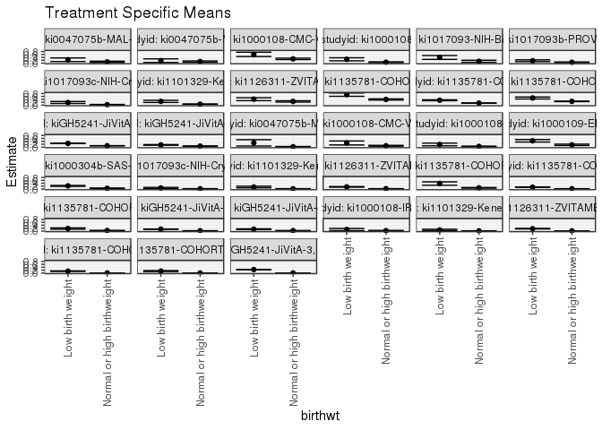

[figure not shown]

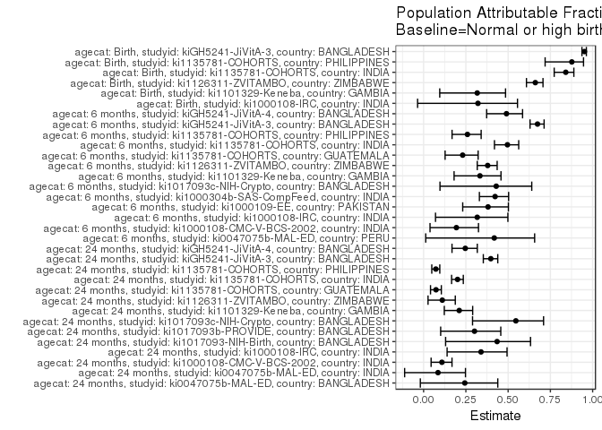

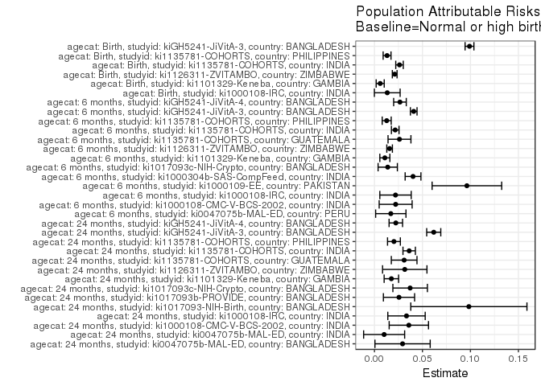

## Results Table

### Parameter: TSM

| agecat | studyid | country | intervention_level | baseline_level | estimate | ci_lower | ci_upper |
| --- | --- | --- | --- | --- | --- | --- | --- |
| Birth | ki1000108-IRC | INDIA | Normal or high birthweight | NA | 0.0281250 | 0.0099871 | 0.0462629 |
| Birth | ki1000108-IRC | INDIA | Low birth weight | NA | 0.1060606 | 0.0316782 | 0.1804431 |
| Birth | ki1101329-Keneba | GAMBIA | Normal or high birthweight | NA | 0.0128480 | 0.0069490 | 0.0187470 |
| Birth | ki1101329-Keneba | GAMBIA | Low birth weight | NA | 0.0785714 | 0.0339865 | 0.1231564 |
| Birth | ki1126311-ZVITAMBO | ZIMBABWE | Normal or high birthweight | NA | 0.0108140 | 0.0089579 | 0.0126700 |
| Birth | ki1126311-ZVITAMBO | ZIMBABWE | Low birth weight | NA | 0.1641241 | 0.1474735 | 0.1807747 |
| Birth | ki1135781-COHORTS | INDIA | Normal or high birthweight | NA | 0.0049355 | 0.0030429 | 0.0068280 |
| Birth | ki1135781-COHORTS | INDIA | Low birth weight | NA | 0.1313869 | 0.1134969 | 0.1492768 |
| Birth | ki1135781-COHORTS | PHILIPPINES | Normal or high birthweight | NA | 0.0018457 | 0.0002291 | 0.0034623 |
| Birth | ki1135781-COHORTS | PHILIPPINES | Low birth weight | NA | 0.1355932 | 0.0965193 | 0.1746672 |
| Birth | kiGH5241-JiVitA-3 | BANGLADESH | Normal or high birthweight | NA | 0.0050469 | 0.0036790 | 0.0064149 |
| Birth | kiGH5241-JiVitA-3 | BANGLADESH | Low birth weight | NA | 0.2385189 | 0.2288163 | 0.2482214 |
| 6 months | ki0047075b-MAL-ED | PERU | Normal or high birthweight | NA | 0.0237154 | 0.0049310 | 0.0424998 |
| 6 months | ki0047075b-MAL-ED | PERU | Low birth weight | NA | 0.2941176 | 0.0771195 | 0.5111158 |
| 6 months | ki1000108-CMC-V-BCS-2002 | INDIA | Normal or high birthweight | NA | 0.0917431 | 0.0604135 | 0.1230727 |
| 6 months | ki1000108-CMC-V-BCS-2002 | INDIA | Low birth weight | NA | 0.2857143 | 0.1489053 | 0.4225233 |
| 6 months | ki1000108-IRC | INDIA | Normal or high birthweight | NA | 0.0471976 | 0.0245957 | 0.0697996 |
| 6 months | ki1000108-IRC | INDIA | Low birth weight | NA | 0.1818182 | 0.0886524 | 0.2749840 |
| 6 months | ki1000109-EE | PAKISTAN | Normal or high birthweight | NA | 0.1563786 | 0.1106496 | 0.2021076 |
| 6 months | ki1000109-EE | PAKISTAN | Low birth weight | NA | 0.4341085 | 0.3484632 | 0.5197538 |
| 6 months | ki1000304b-SAS-CompFeed | INDIA | Normal or high birthweight | NA | 0.0548355 | 0.0386045 | 0.0710665 |
| 6 months | ki1000304b-SAS-CompFeed | INDIA | Low birth weight | NA | 0.2198142 | 0.1864957 | 0.2531328 |
| 6 months | ki1017093c-NIH-Crypto | BANGLADESH | Normal or high birthweight | NA | 0.0183486 | 0.0070732 | 0.0296241 |
| 6 months | ki1017093c-NIH-Crypto | BANGLADESH | Low birth weight | NA | 0.0764706 | 0.0364945 | 0.1164467 |
| 6 months | ki1101329-Keneba | GAMBIA | Normal or high birthweight | NA | 0.0216423 | 0.0144447 | 0.0288398 |
| 6 months | ki1101329-Keneba | GAMBIA | Low birth weight | NA | 0.1428571 | 0.0875742 | 0.1981401 |
| 6 months | ki1126311-ZVITAMBO | ZIMBABWE | Normal or high birthweight | NA | 0.0258466 | 0.0221900 | 0.0295031 |
| 6 months | ki1126311-ZVITAMBO | ZIMBABWE | Low birth weight | NA | 0.1524272 | 0.1304751 | 0.1743793 |
| 6 months | ki1135781-COHORTS | GUATEMALA | Normal or high birthweight | NA | 0.0867710 | 0.0659486 | 0.1075933 |
| 6 months | ki1135781-COHORTS | GUATEMALA | Low birth weight | NA | 0.3823529 | 0.2667742 | 0.4979317 |
| 6 months | ki1135781-COHORTS | INDIA | Normal or high birthweight | NA | 0.0219780 | 0.0179159 | 0.0260401 |
| 6 months | ki1135781-COHORTS | INDIA | Low birth weight | NA | 0.1297771 | 0.1111904 | 0.1483638 |
| 6 months | ki1135781-COHORTS | PHILIPPINES | Normal or high birthweight | NA | 0.0363937 | 0.0289281 | 0.0438593 |
| 6 months | ki1135781-COHORTS | PHILIPPINES | Low birth weight | NA | 0.1733871 | 0.1262608 | 0.2205134 |
| 6 months | kiGH5241-JiVitA-3 | BANGLADESH | Normal or high birthweight | NA | 0.0197936 | 0.0168922 | 0.0226950 |
| 6 months | kiGH5241-JiVitA-3 | BANGLADESH | Low birth weight | NA | 0.1324013 | 0.1235886 | 0.1412140 |
| 6 months | kiGH5241-JiVitA-4 | BANGLADESH | Normal or high birthweight | NA | 0.0276298 | 0.0200076 | 0.0352520 |
| 6 months | kiGH5241-JiVitA-4 | BANGLADESH | Low birth weight | NA | 0.1311475 | 0.1075919 | 0.1547032 |
| 24 months | ki0047075b-MAL-ED | BANGLADESH | Normal or high birthweight | NA | 0.0909091 | 0.0469387 | 0.1348794 |
| 24 months | ki0047075b-MAL-ED | BANGLADESH | Low birth weight | NA | 0.2325581 | 0.1059829 | 0.3591334 |
| 24 months | ki0047075b-MAL-ED | INDIA | Normal or high birthweight | NA | 0.1081081 | 0.0632608 | 0.1529555 |
| 24 months | ki0047075b-MAL-ED | INDIA | Low birth weight | NA | 0.1714286 | 0.0462846 | 0.2965725 |
| 24 months | ki1000108-CMC-V-BCS-2002 | INDIA | Normal or high birthweight | NA | 0.2948328 | 0.2454963 | 0.3441694 |
| 24 months | ki1000108-CMC-V-BCS-2002 | INDIA | Low birth weight | NA | 0.6046512 | 0.4583186 | 0.7509838 |
| 24 months | ki1000108-IRC | INDIA | Normal or high birthweight | NA | 0.0648968 | 0.0386410 | 0.0911525 |
| 24 months | ki1000108-IRC | INDIA | Low birth weight | NA | 0.2647059 | 0.1597178 | 0.3696940 |
| 24 months | ki1017093-NIH-Birth | BANGLADESH | Normal or high birthweight | NA | 0.1279070 | 0.0570605 | 0.1987534 |
| 24 months | ki1017093-NIH-Birth | BANGLADESH | Low birth weight | NA | 0.3921569 | 0.2576701 | 0.5266436 |
| 24 months | ki1017093b-PROVIDE | BANGLADESH | Normal or high birthweight | NA | 0.0593607 | 0.0372120 | 0.0815095 |
| 24 months | ki1017093b-PROVIDE | BANGLADESH | Low birth weight | NA | 0.1654676 | 0.1036382 | 0.2272971 |
| 24 months | ki1017093c-NIH-Crypto | BANGLADESH | Normal or high birthweight | NA | 0.0309278 | 0.0136850 | 0.0481706 |
| 24 months | ki1017093c-NIH-Crypto | BANGLADESH | Low birth weight | NA | 0.1825397 | 0.1150251 | 0.2500543 |
| 24 months | ki1101329-Keneba | GAMBIA | Normal or high birthweight | NA | 0.0659509 | 0.0524751 | 0.0794268 |
| 24 months | ki1101329-Keneba | GAMBIA | Low birth weight | NA | 0.2575758 | 0.1829496 | 0.3322019 |
| 24 months | ki1126311-ZVITAMBO | ZIMBABWE | Normal or high birthweight | NA | 0.2541436 | 0.2092444 | 0.2990429 |
| 24 months | ki1126311-ZVITAMBO | ZIMBABWE | Low birth weight | NA | 0.4086022 | 0.3085850 | 0.5086193 |
| 24 months | ki1135781-COHORTS | GUATEMALA | Normal or high birthweight | NA | 0.3902027 | 0.3508787 | 0.4295267 |
| 24 months | ki1135781-COHORTS | GUATEMALA | Low birth weight | NA | 0.7213115 | 0.6087119 | 0.8339111 |
| 24 months | ki1135781-COHORTS | INDIA | Normal or high birthweight | NA | 0.1438339 | 0.1328878 | 0.1547800 |
| 24 months | ki1135781-COHORTS | INDIA | Low birth weight | NA | 0.3366228 | 0.3059504 | 0.3672952 |
| 24 months | ki1135781-COHORTS | PHILIPPINES | Normal or high birthweight | NA | 0.2602552 | 0.2418915 | 0.2786190 |
| 24 months | ki1135781-COHORTS | PHILIPPINES | Low birth weight | NA | 0.4905660 | 0.4232586 | 0.5578735 |
| 24 months | kiGH5241-JiVitA-3 | BANGLADESH | Normal or high birthweight | NA | 0.0936393 | 0.0849375 | 0.1023410 |
| 24 months | kiGH5241-JiVitA-3 | BANGLADESH | Low birth weight | NA | 0.2581446 | 0.2412160 | 0.2750732 |
| 24 months | kiGH5241-JiVitA-4 | BANGLADESH | Normal or high birthweight | NA | 0.0680203 | 0.0574358 | 0.0786048 |
| 24 months | kiGH5241-JiVitA-4 | BANGLADESH | Low birth weight | NA | 0.1526066 | 0.1283445 | 0.1768688 |

### Parameter: E(Y)

| agecat | studyid | country | intervention_level | baseline_level | estimate | ci_lower | ci_upper |
| --- | --- | --- | --- | --- | --- | --- | --- |
| Birth | ki1000108-IRC | INDIA | NA | NA | 0.0414508 | 0.0215399 | 0.0613617 |
| Birth | ki1101329-Keneba | GAMBIA | NA | NA | 0.0188189 | 0.0120322 | 0.0256057 |
| Birth | ki1126311-ZVITAMBO | ZIMBABWE | NA | NA | 0.0318872 | 0.0289588 | 0.0348156 |
| Birth | ki1135781-COHORTS | INDIA | NA | NA | 0.0310334 | 0.0268616 | 0.0352053 |
| Birth | ki1135781-COHORTS | PHILIPPINES | NA | NA | 0.0149800 | 0.0106354 | 0.0193246 |
| Birth | kiGH5241-JiVitA-3 | BANGLADESH | NA | NA | 0.1040689 | 0.0993991 | 0.1087387 |
| 6 months | ki0047075b-MAL-ED | PERU | NA | NA | 0.0407407 | 0.0171167 | 0.0643648 |
| 6 months | ki1000108-CMC-V-BCS-2002 | INDIA | NA | NA | 0.1138211 | 0.0813725 | 0.1462698 |
| 6 months | ki1000108-IRC | INDIA | NA | NA | 0.0691358 | 0.0443985 | 0.0938731 |
| 6 months | ki1000109-EE | PAKISTAN | NA | NA | 0.2526882 | 0.2084696 | 0.2969067 |
| 6 months | ki1000304b-SAS-CompFeed | INDIA | NA | NA | 0.0950226 | 0.0765320 | 0.1135132 |
| 6 months | ki1017093c-NIH-Crypto | BANGLADESH | NA | NA | 0.0321678 | 0.0192256 | 0.0451101 |
| 6 months | ki1101329-Keneba | GAMBIA | NA | NA | 0.0324638 | 0.0240979 | 0.0408297 |
| 6 months | ki1126311-ZVITAMBO | ZIMBABWE | NA | NA | 0.0416213 | 0.0373152 | 0.0459273 |
| 6 months | ki1135781-COHORTS | GUATEMALA | NA | NA | 0.1128405 | 0.0904926 | 0.1351883 |
| 6 months | ki1135781-COHORTS | INDIA | NA | NA | 0.0436033 | 0.0385446 | 0.0486620 |
| 6 months | ki1135781-COHORTS | PHILIPPINES | NA | NA | 0.0491373 | 0.0409307 | 0.0573439 |
| 6 months | kiGH5241-JiVitA-3 | BANGLADESH | NA | NA | 0.0606930 | 0.0568470 | 0.0645389 |
| 6 months | kiGH5241-JiVitA-4 | BANGLADESH | NA | NA | 0.0541945 | 0.0457550 | 0.0626340 |
| 24 months | ki0047075b-MAL-ED | BANGLADESH | NA | NA | 0.1201923 | 0.0758932 | 0.1644914 |
| 24 months | ki0047075b-MAL-ED | INDIA | NA | NA | 0.1181818 | 0.0754264 | 0.1609372 |
| 24 months | ki1000108-CMC-V-BCS-2002 | INDIA | NA | NA | 0.3306452 | 0.2827744 | 0.3785159 |
| 24 months | ki1000108-IRC | INDIA | NA | NA | 0.0982801 | 0.0693231 | 0.1272371 |
| 24 months | ki1017093-NIH-Birth | BANGLADESH | NA | NA | 0.2262774 | 0.1559553 | 0.2965995 |
| 24 months | ki1017093b-PROVIDE | BANGLADESH | NA | NA | 0.0849220 | 0.0621566 | 0.1076874 |
| 24 months | ki1017093c-NIH-Crypto | BANGLADESH | NA | NA | 0.0680934 | 0.0462948 | 0.0898920 |
| 24 months | ki1101329-Keneba | GAMBIA | NA | NA | 0.0835655 | 0.0692473 | 0.0978836 |
| 24 months | ki1126311-ZVITAMBO | ZIMBABWE | NA | NA | 0.2857143 | 0.2441594 | 0.3272692 |
| 24 months | ki1135781-COHORTS | GUATEMALA | NA | NA | 0.4211332 | 0.3832346 | 0.4590318 |
| 24 months | ki1135781-COHORTS | INDIA | NA | NA | 0.1800041 | 0.1692028 | 0.1908054 |
| 24 months | ki1135781-COHORTS | PHILIPPINES | NA | NA | 0.2805486 | 0.2625932 | 0.2985040 |
| 24 months | kiGH5241-JiVitA-3 | BANGLADESH | NA | NA | 0.1554054 | 0.1466191 | 0.1641917 |
| 24 months | kiGH5241-JiVitA-4 | BANGLADESH | NA | NA | 0.0902743 | 0.0800792 | 0.1004695 |

### Parameter: RR

| agecat | studyid | country | intervention_level | baseline_level | estimate | ci_lower | ci_upper |
| --- | --- | --- | --- | --- | --- | --- | --- |
| Birth | ki1000108-IRC | INDIA | Normal or high birthweight | Normal or high birthweight | 1.000000 | 1.0000000 | 1.000000 |
| Birth | ki1000108-IRC | INDIA | Low birth weight | Normal or high birthweight | 3.771044 | 1.4543975 | 9.777775 |
| Birth | ki1101329-Keneba | GAMBIA | Normal or high birthweight | Normal or high birthweight | 1.000000 | 1.0000000 | 1.000000 |
| Birth | ki1101329-Keneba | GAMBIA | Low birth weight | Normal or high birthweight | 6.115476 | 2.9472993 | 12.689261 |
| Birth | ki1126311-ZVITAMBO | ZIMBABWE | Normal or high birthweight | Normal or high birthweight | 1.000000 | 1.0000000 | 1.000000 |
| Birth | ki1126311-ZVITAMBO | ZIMBABWE | Low birth weight | Normal or high birthweight | 15.177030 | 12.4336447 | 18.525723 |
| Birth | ki1135781-COHORTS | INDIA | Normal or high birthweight | Normal or high birthweight | 1.000000 | 1.0000000 | 1.000000 |
| Birth | ki1135781-COHORTS | INDIA | Low birth weight | Normal or high birthweight | 26.620999 | 17.7215809 | 39.989525 |
| Birth | ki1135781-COHORTS | PHILIPPINES | Normal or high birthweight | Normal or high birthweight | 1.000000 | 1.0000000 | 1.000000 |
| Birth | ki1135781-COHORTS | PHILIPPINES | Low birth weight | Normal or high birthweight | 73.464407 | 29.2170860 | 184.721332 |
| Birth | kiGH5241-JiVitA-3 | BANGLADESH | Normal or high birthweight | Normal or high birthweight | 1.000000 | 1.0000000 | 1.000000 |
| Birth | kiGH5241-JiVitA-3 | BANGLADESH | Low birth weight | Normal or high birthweight | 47.260213 | 35.9860060 | 62.066565 |
| 6 months | ki0047075b-MAL-ED | PERU | Normal or high birthweight | Normal or high birthweight | 1.000000 | 1.0000000 | 1.000000 |
| 6 months | ki0047075b-MAL-ED | PERU | Low birth weight | Normal or high birthweight | 12.401961 | 4.2012963 | 36.609803 |
| 6 months | ki1000108-CMC-V-BCS-2002 | INDIA | Normal or high birthweight | Normal or high birthweight | 1.000000 | 1.0000000 | 1.000000 |
| 6 months | ki1000108-CMC-V-BCS-2002 | INDIA | Low birth weight | Normal or high birthweight | 3.114286 | 1.7295651 | 5.607638 |
| 6 months | ki1000108-IRC | INDIA | Normal or high birthweight | Normal or high birthweight | 1.000000 | 1.0000000 | 1.000000 |
| 6 months | ki1000108-IRC | INDIA | Low birth weight | Normal or high birthweight | 3.852273 | 1.9104015 | 7.768003 |
| 6 months | ki1000109-EE | PAKISTAN | Normal or high birthweight | Normal or high birthweight | 1.000000 | 1.0000000 | 1.000000 |
| 6 months | ki1000109-EE | PAKISTAN | Low birth weight | Normal or high birthweight | 2.776010 | 1.9508399 | 3.950211 |
| 6 months | ki1000304b-SAS-CompFeed | INDIA | Normal or high birthweight | Normal or high birthweight | 1.000000 | 1.0000000 | 1.000000 |
| 6 months | ki1000304b-SAS-CompFeed | INDIA | Low birth weight | Normal or high birthweight | 4.008612 | 2.9791380 | 5.393833 |
| 6 months | ki1017093c-NIH-Crypto | BANGLADESH | Normal or high birthweight | Normal or high birthweight | 1.000000 | 1.0000000 | 1.000000 |
| 6 months | ki1017093c-NIH-Crypto | BANGLADESH | Low birth weight | Normal or high birthweight | 4.167647 | 1.8599751 | 9.338448 |
| 6 months | ki1101329-Keneba | GAMBIA | Normal or high birthweight | Normal or high birthweight | 1.000000 | 1.0000000 | 1.000000 |
| 6 months | ki1101329-Keneba | GAMBIA | Low birth weight | Normal or high birthweight | 6.600840 | 3.9627770 | 10.995091 |
| 6 months | ki1126311-ZVITAMBO | ZIMBABWE | Normal or high birthweight | Normal or high birthweight | 1.000000 | 1.0000000 | 1.000000 |
| 6 months | ki1126311-ZVITAMBO | ZIMBABWE | Low birth weight | Normal or high birthweight | 5.897383 | 4.8193084 | 7.216623 |
| 6 months | ki1135781-COHORTS | GUATEMALA | Normal or high birthweight | Normal or high birthweight | 1.000000 | 1.0000000 | 1.000000 |
| 6 months | ki1135781-COHORTS | GUATEMALA | Low birth weight | Normal or high birthweight | 4.406461 | 2.9955222 | 6.481974 |
| 6 months | ki1135781-COHORTS | INDIA | Normal or high birthweight | Normal or high birthweight | 1.000000 | 1.0000000 | 1.000000 |
| 6 months | ki1135781-COHORTS | INDIA | Low birth weight | Normal or high birthweight | 5.904857 | 4.6737142 | 7.460305 |
| 6 months | ki1135781-COHORTS | PHILIPPINES | Normal or high birthweight | Normal or high birthweight | 1.000000 | 1.0000000 | 1.000000 |
| 6 months | ki1135781-COHORTS | PHILIPPINES | Low birth weight | Normal or high birthweight | 4.764204 | 3.3892547 | 6.696943 |
| 6 months | kiGH5241-JiVitA-3 | BANGLADESH | Normal or high birthweight | Normal or high birthweight | 1.000000 | 1.0000000 | 1.000000 |
| 6 months | kiGH5241-JiVitA-3 | BANGLADESH | Low birth weight | Normal or high birthweight | 6.689090 | 5.7000543 | 7.849737 |
| 6 months | kiGH5241-JiVitA-4 | BANGLADESH | Normal or high birthweight | Normal or high birthweight | 1.000000 | 1.0000000 | 1.000000 |
| 6 months | kiGH5241-JiVitA-4 | BANGLADESH | Low birth weight | Normal or high birthweight | 4.746593 | 3.4154436 | 6.596550 |
| 24 months | ki0047075b-MAL-ED | BANGLADESH | Normal or high birthweight | Normal or high birthweight | 1.000000 | 1.0000000 | 1.000000 |
| 24 months | ki0047075b-MAL-ED | BANGLADESH | Low birth weight | Normal or high birthweight | 2.558139 | 1.2350971 | 5.298432 |
| 24 months | ki0047075b-MAL-ED | INDIA | Normal or high birthweight | Normal or high birthweight | 1.000000 | 1.0000000 | 1.000000 |
| 24 months | ki0047075b-MAL-ED | INDIA | Low birth weight | Normal or high birthweight | 1.585714 | 0.6848141 | 3.671784 |
| 24 months | ki1000108-CMC-V-BCS-2002 | INDIA | Normal or high birthweight | Normal or high birthweight | 1.000000 | 1.0000000 | 1.000000 |
| 24 months | ki1000108-CMC-V-BCS-2002 | INDIA | Low birth weight | Normal or high birthweight | 2.050827 | 1.5280815 | 2.752400 |
| 24 months | ki1000108-IRC | INDIA | Normal or high birthweight | Normal or high birthweight | 1.000000 | 1.0000000 | 1.000000 |
| 24 months | ki1000108-IRC | INDIA | Low birth weight | Normal or high birthweight | 4.078877 | 2.3146558 | 7.187780 |
| 24 months | ki1017093-NIH-Birth | BANGLADESH | Normal or high birthweight | Normal or high birthweight | 1.000000 | 1.0000000 | 1.000000 |
| 24 months | ki1017093-NIH-Birth | BANGLADESH | Low birth weight | Normal or high birthweight | 3.065954 | 1.5982290 | 5.881555 |
| 24 months | ki1017093b-PROVIDE | BANGLADESH | Normal or high birthweight | Normal or high birthweight | 1.000000 | 1.0000000 | 1.000000 |
| 24 months | ki1017093b-PROVIDE | BANGLADESH | Low birth weight | Normal or high birthweight | 2.787493 | 1.6439224 | 4.726572 |
| 24 months | ki1017093c-NIH-Crypto | BANGLADESH | Normal or high birthweight | Normal or high birthweight | 1.000000 | 1.0000000 | 1.000000 |
| 24 months | ki1017093c-NIH-Crypto | BANGLADESH | Low birth weight | Normal or high birthweight | 5.902116 | 3.0230430 | 11.523150 |
| 24 months | ki1101329-Keneba | GAMBIA | Normal or high birthweight | Normal or high birthweight | 1.000000 | 1.0000000 | 1.000000 |
| 24 months | ki1101329-Keneba | GAMBIA | Low birth weight | Normal or high birthweight | 3.905567 | 2.7397661 | 5.567430 |
| 24 months | ki1126311-ZVITAMBO | ZIMBABWE | Normal or high birthweight | Normal or high birthweight | 1.000000 | 1.0000000 | 1.000000 |
| 24 months | ki1126311-ZVITAMBO | ZIMBABWE | Low birth weight | Normal or high birthweight | 1.607761 | 1.1888272 | 2.174323 |
| 24 months | ki1135781-COHORTS | GUATEMALA | Normal or high birthweight | Normal or high birthweight | 1.000000 | 1.0000000 | 1.000000 |
| 24 months | ki1135781-COHORTS | GUATEMALA | Low birth weight | Normal or high birthweight | 1.848556 | 1.5351012 | 2.226015 |
| 24 months | ki1135781-COHORTS | INDIA | Normal or high birthweight | Normal or high birthweight | 1.000000 | 1.0000000 | 1.000000 |
| 24 months | ki1135781-COHORTS | INDIA | Low birth weight | Normal or high birthweight | 2.340358 | 2.0783737 | 2.635367 |
| 24 months | ki1135781-COHORTS | PHILIPPINES | Normal or high birthweight | Normal or high birthweight | 1.000000 | 1.0000000 | 1.000000 |
| 24 months | ki1135781-COHORTS | PHILIPPINES | Low birth weight | Normal or high birthweight | 1.884942 | 1.6154489 | 2.199393 |
| 24 months | kiGH5241-JiVitA-3 | BANGLADESH | Normal or high birthweight | Normal or high birthweight | 1.000000 | 1.0000000 | 1.000000 |
| 24 months | kiGH5241-JiVitA-3 | BANGLADESH | Low birth weight | Normal or high birthweight | 2.756799 | 2.4619863 | 3.086914 |
| 24 months | kiGH5241-JiVitA-4 | BANGLADESH | Normal or high birthweight | Normal or high birthweight | 1.000000 | 1.0000000 | 1.000000 |
| 24 months | kiGH5241-JiVitA-4 | BANGLADESH | Low birth weight | Normal or high birthweight | 2.243545 | 1.7959582 | 2.802680 |

### Parameter: PAR

| agecat | studyid | country | intervention_level | baseline_level | estimate | ci_lower | ci_upper |
| --- | --- | --- | --- | --- | --- | --- | --- |
| Birth | ki1000108-IRC | INDIA | Normal or high birthweight | NA | 0.0133258 | -0.0000892 | 0.0267408 |
| Birth | ki1101329-Keneba | GAMBIA | Normal or high birthweight | NA | 0.0059710 | 0.0017776 | 0.0101643 |
| Birth | ki1126311-ZVITAMBO | ZIMBABWE | Normal or high birthweight | NA | 0.0210732 | 0.0186080 | 0.0235384 |
| Birth | ki1135781-COHORTS | INDIA | Normal or high birthweight | NA | 0.0260980 | 0.0221863 | 0.0300097 |
| Birth | ki1135781-COHORTS | PHILIPPINES | Normal or high birthweight | NA | 0.0131343 | 0.0090385 | 0.0172301 |
| Birth | kiGH5241-JiVitA-3 | BANGLADESH | Normal or high birthweight | NA | 0.0990220 | 0.0944148 | 0.1036292 |
| 6 months | ki0047075b-MAL-ED | PERU | Normal or high birthweight | NA | 0.0170253 | 0.0012242 | 0.0328265 |
| 6 months | ki1000108-CMC-V-BCS-2002 | INDIA | Normal or high birthweight | NA | 0.0220780 | 0.0049079 | 0.0392481 |
| 6 months | ki1000108-IRC | INDIA | Normal or high birthweight | NA | 0.0219382 | 0.0055802 | 0.0382961 |
| 6 months | ki1000109-EE | PAKISTAN | Normal or high birthweight | NA | 0.0963096 | 0.0600543 | 0.1325649 |
| 6 months | ki1000304b-SAS-CompFeed | INDIA | Normal or high birthweight | NA | 0.0401871 | 0.0319661 | 0.0484082 |
| 6 months | ki1017093c-NIH-Crypto | BANGLADESH | Normal or high birthweight | NA | 0.0138192 | 0.0037782 | 0.0238602 |
| 6 months | ki1101329-Keneba | GAMBIA | Normal or high birthweight | NA | 0.0108215 | 0.0055838 | 0.0160592 |
| 6 months | ki1126311-ZVITAMBO | ZIMBABWE | Normal or high birthweight | NA | 0.0157747 | 0.0128585 | 0.0186909 |
| 6 months | ki1135781-COHORTS | GUATEMALA | Normal or high birthweight | NA | 0.0260695 | 0.0141390 | 0.0380000 |
| 6 months | ki1135781-COHORTS | INDIA | Normal or high birthweight | NA | 0.0216252 | 0.0176616 | 0.0255888 |
| 6 months | ki1135781-COHORTS | PHILIPPINES | Normal or high birthweight | NA | 0.0127436 | 0.0080550 | 0.0174321 |
| 6 months | kiGH5241-JiVitA-3 | BANGLADESH | Normal or high birthweight | NA | 0.0408993 | 0.0374379 | 0.0443607 |
| 6 months | kiGH5241-JiVitA-4 | BANGLADESH | Normal or high birthweight | NA | 0.0265647 | 0.0199957 | 0.0331336 |
| 24 months | ki0047075b-MAL-ED | BANGLADESH | Normal or high birthweight | NA | 0.0292832 | 0.0005012 | 0.0580652 |
| 24 months | ki0047075b-MAL-ED | INDIA | Normal or high birthweight | NA | 0.0100737 | -0.0112967 | 0.0314441 |
| 24 months | ki1000108-CMC-V-BCS-2002 | INDIA | Normal or high birthweight | NA | 0.0358123 | 0.0153126 | 0.0563120 |
| 24 months | ki1000108-IRC | INDIA | Normal or high birthweight | NA | 0.0333833 | 0.0139026 | 0.0528641 |
| 24 months | ki1017093-NIH-Birth | BANGLADESH | Normal or high birthweight | NA | 0.0983704 | 0.0378484 | 0.1588924 |
| 24 months | ki1017093b-PROVIDE | BANGLADESH | Normal or high birthweight | NA | 0.0255613 | 0.0093115 | 0.0418110 |
| 24 months | ki1017093c-NIH-Crypto | BANGLADESH | Normal or high birthweight | NA | 0.0371656 | 0.0191759 | 0.0551552 |
| 24 months | ki1101329-Keneba | GAMBIA | Normal or high birthweight | NA | 0.0176145 | 0.0100782 | 0.0251509 |
| 24 months | ki1126311-ZVITAMBO | ZIMBABWE | Normal or high birthweight | NA | 0.0315706 | 0.0084413 | 0.0547000 |
| 24 months | ki1135781-COHORTS | GUATEMALA | Normal or high birthweight | NA | 0.0309305 | 0.0175576 | 0.0443035 |
| 24 months | ki1135781-COHORTS | INDIA | Normal or high birthweight | NA | 0.0361702 | 0.0297041 | 0.0426364 |
| 24 months | ki1135781-COHORTS | PHILIPPINES | Normal or high birthweight | NA | 0.0202934 | 0.0136152 | 0.0269716 |
| 24 months | kiGH5241-JiVitA-3 | BANGLADESH | Normal or high birthweight | NA | 0.0617662 | 0.0544278 | 0.0691045 |
| 24 months | kiGH5241-JiVitA-4 | BANGLADESH | Normal or high birthweight | NA | 0.0222540 | 0.0152314 | 0.0292766 |

### Parameter: PAF

| agecat | studyid | country | intervention_level | baseline_level | estimate | ci_lower | ci_upper |
| --- | --- | --- | --- | --- | --- | --- | --- |
| Birth | ki1000108-IRC | INDIA | Normal or high birthweight | NA | 0.3214844 | -0.0355573 | 0.5554244 |
| Birth | ki1101329-Keneba | GAMBIA | Normal or high birthweight | NA | 0.3172857 | 0.0954394 | 0.4847235 |
| Birth | ki1126311-ZVITAMBO | ZIMBABWE | Normal or high birthweight | NA | 0.6608676 | 0.6084475 | 0.7062699 |
| Birth | ki1135781-COHORTS | INDIA | Normal or high birthweight | NA | 0.8409632 | 0.7725567 | 0.8887956 |
| Birth | ki1135781-COHORTS | PHILIPPINES | Normal or high birthweight | NA | 0.8767893 | 0.7188230 | 0.9460095 |
| Birth | kiGH5241-JiVitA-3 | BANGLADESH | Normal or high birthweight | NA | 0.9515040 | 0.9367189 | 0.9628347 |
| 6 months | ki0047075b-MAL-ED | PERU | Normal or high birthweight | NA | 0.4178944 | 0.0126231 | 0.6568210 |
| 6 months | ki1000108-CMC-V-BCS-2002 | INDIA | Normal or high birthweight | NA | 0.1939712 | 0.0379931 | 0.3246592 |
| 6 months | ki1000108-IRC | INDIA | Normal or high birthweight | NA | 0.3173198 | 0.0704719 | 0.4986142 |
| 6 months | ki1000109-EE | PAKISTAN | Normal or high birthweight | NA | 0.3811400 | 0.2313258 | 0.5017555 |
| 6 months | ki1000304b-SAS-CompFeed | INDIA | Normal or high birthweight | NA | 0.4229217 | 0.3300385 | 0.5029276 |
| 6 months | ki1017093c-NIH-Crypto | BANGLADESH | Normal or high birthweight | NA | 0.4295971 | 0.0969022 | 0.6397296 |
| 6 months | ki1101329-Keneba | GAMBIA | Normal or high birthweight | NA | 0.3333409 | 0.1802996 | 0.4578088 |
| 6 months | ki1126311-ZVITAMBO | ZIMBABWE | Normal or high birthweight | NA | 0.3790059 | 0.3173591 | 0.4350856 |
| 6 months | ki1135781-COHORTS | GUATEMALA | Normal or high birthweight | NA | 0.2310296 | 0.1271465 | 0.3225489 |
| 6 months | ki1135781-COHORTS | INDIA | Normal or high birthweight | NA | 0.4959546 | 0.4191970 | 0.5625681 |
| 6 months | ki1135781-COHORTS | PHILIPPINES | Normal or high birthweight | NA | 0.2593463 | 0.1683110 | 0.3404170 |
| 6 months | kiGH5241-JiVitA-3 | BANGLADESH | Normal or high birthweight | NA | 0.6738728 | 0.6296712 | 0.7127986 |
| 6 months | kiGH5241-JiVitA-4 | BANGLADESH | Normal or high birthweight | NA | 0.4901729 | 0.3729869 | 0.5854574 |
| 24 months | ki0047075b-MAL-ED | BANGLADESH | Normal or high birthweight | NA | 0.2436364 | -0.0193728 | 0.4387863 |
| 24 months | ki0047075b-MAL-ED | INDIA | Normal or high birthweight | NA | 0.0852391 | -0.1122687 | 0.2476750 |
| 24 months | ki1000108-CMC-V-BCS-2002 | INDIA | Normal or high birthweight | NA | 0.1083105 | 0.0443587 | 0.1679826 |
| 24 months | ki1000108-IRC | INDIA | Normal or high birthweight | NA | 0.3396755 | 0.1389587 | 0.4936034 |
| 24 months | ki1017093-NIH-Birth | BANGLADESH | Normal or high birthweight | NA | 0.4347337 | 0.1302801 | 0.6326105 |
| 24 months | ki1017093b-PROVIDE | BANGLADESH | Normal or high birthweight | NA | 0.3009971 | 0.1009577 | 0.4565272 |
| 24 months | ki1017093c-NIH-Crypto | BANGLADESH | Normal or high birthweight | NA | 0.5458027 | 0.2895240 | 0.7096380 |
| 24 months | ki1101329-Keneba | GAMBIA | Normal or high birthweight | NA | 0.2107873 | 0.1224150 | 0.2902606 |
| 24 months | ki1126311-ZVITAMBO | ZIMBABWE | Normal or high birthweight | NA | 0.1104972 | 0.0262516 | 0.1874542 |
| 24 months | ki1135781-COHORTS | GUATEMALA | Normal or high birthweight | NA | 0.0734459 | 0.0408938 | 0.1048932 |
| 24 months | ki1135781-COHORTS | INDIA | Normal or high birthweight | NA | 0.2009411 | 0.1655984 | 0.2347869 |
| 24 months | ki1135781-COHORTS | PHILIPPINES | Normal or high birthweight | NA | 0.0723347 | 0.0483505 | 0.0957143 |
| 24 months | kiGH5241-JiVitA-3 | BANGLADESH | Normal or high birthweight | NA | 0.3974518 | 0.3531916 | 0.4386833 |
| 24 months | kiGH5241-JiVitA-4 | BANGLADESH | Normal or high birthweight | NA | 0.2465154 | 0.1679911 | 0.3176286 |